# EDA - Problema de clasificación - Adult

### Objetivo

Predecir si los ingresos anuales de una persona superan los $50K

### Data

https://archive.ics.uci.edu/dataset/2/adult

## 0. Carga de librerías

```python
import sys
from pathlib import Path
import pandas as pd
from sklearn.impute import KNNImputer
import numpy as np
import seaborn as sns
import matplotlib.pyplot as plt
```

## 1. Carga de Datos

```python
# Añade el directorio raíz del proyecto al sys.path
PROJECT_ROOT = Path.cwd().parent
sys.path.append(str(PROJECT_ROOT))

from rfh_testdatascience_1.config import RAW_DATA_DIR

# Paths a los archivos
train_path = RAW_DATA_DIR / "adult.data"
test_path = RAW_DATA_DIR / "adult.test"

# Leer los datos de entrenamiento
df_train = pd.read_csv(train_path)

# Leer los datos de prueba
df_test = pd.read_csv(test_path)
```

```
2025-08-02 13:56:40.690 | INFO     | rfh_testdatascience_1.config:<module>:11 - PROJ_ROOT path is: C:\Users\Usuario\Desktop\Capgemini\RFH-TestDataScience-1\rfh_testdatascience_1
```

## 2. Revisión inicial

```python
# Mostrar primeras filas
print(df_train.head())
print('------------------------------------------------')
print(df_test.head())
```

```
   39          State-gov   77516   Bachelors   13        Never-married  \
0  50   Self-emp-not-inc   83311   Bachelors   13   Married-civ-spouse
1  38            Private  215646     HS-grad    9             Divorced
2  53            Private  234721        11th    7   Married-civ-spouse
3  28            Private  338409   Bachelors   13   Married-civ-spouse
4  37            Private  284582     Masters   14   Married-civ-spouse

         Adm-clerical   Not-in-family   White     Male   2174   0   40  \
0     Exec-managerial         Husband   White     Male      0   0   13
1   Handlers-cleaners   Not-in-family   White     Male      0   0   40
2   Handlers-cleaners         Husband   Black     Male      0   0   40
3      Prof-specialty            Wife   Black   Female      0   0   40
4     Exec-managerial            Wife   White   Female      0   0   40

    United-States   <=50K
0   United-States   <=50K
1   United-States   <=50K
2   United-States   <=50K
3            Cuba   <=50K
4   United-States   <=50K
------------------------------------------------
                                                                                                                        |1x3 Cross validator
25 Private   226802 11th         7  Never-married      Machine-op-inspct Own-child Black Male   0    0 40 United-States               <=50K.
38 Private   89814  HS-grad      9  Married-civ-spouse Farming-fishing   Husband   White Male   0    0 50 United-States               <=50K.
28 Local-gov 336951 Assoc-acdm   12 Married-civ-spouse Protective-serv   Husband   White Male   0    0 40 United-States                >50K.
44 Private   160323 Some-college 10 Married-civ-spouse Machine-op-inspct Husband   Black Male   7688 0 40 United-States                >50K.
18 ?         103497 Some-college 10 Never-married      ?                 Own-child White Female 0    0 30 United-States               <=50K.
```

### Insights

- Falta incluir las cabeceras → se encuentran en el archivo adult.name.
- Los valores nulos están representados con ?.
- Revisar la primera línea del archivo test.

```python
# Nombres de columnas (según adult.names)
column_names = [
    "age", "workclass", "fnlwgt", "education", "education-num",
    "marital-status", "occupation", "relationship", "race", "sex",
    "capital-gain", "capital-loss", "hours-per-week", "native-country", "income"
]

# Leer los datos de entrenamiento
df_train = pd.read_csv(train_path, header=None, names=column_names, na_values=" ?")

# Leer los datos de prueba
df_test = pd.read_csv(test_path, header=0, names=column_names, na_values=" ?")
```

```python
# Mostrar primeras filas
print(df_train.head())
print('------------------------------------------------')
print(df_test.head())
```

```
   age          workclass  fnlwgt   education  education-num  \
0   39          State-gov   77516   Bachelors             13
1   50   Self-emp-not-inc   83311   Bachelors             13
2   38            Private  215646     HS-grad              9
3   53            Private  234721        11th              7
4   28            Private  338409   Bachelors             13

        marital-status          occupation    relationship    race      sex  \
0        Never-married        Adm-clerical   Not-in-family   White     Male
1   Married-civ-spouse     Exec-managerial         Husband   White     Male
2             Divorced   Handlers-cleaners   Not-in-family   White     Male
3   Married-civ-spouse   Handlers-cleaners         Husband   Black     Male
4   Married-civ-spouse      Prof-specialty            Wife   Black   Female

   capital-gain  capital-loss  hours-per-week  native-country  income
```

[output cut: 26 more lines]

```python
# Forma
print(df_train.shape)
print('------------------------------------------------')
print(df_test.shape)
```

```
(32561, 15)
------------------------------------------------
(16281, 15)
```

```python
# Tipos de datos
print(df_train.dtypes)
print('------------------------------------------------')
print(df_test.dtypes)
```

```
age                int64
workclass         object
fnlwgt             int64
education         object
education-num      int64
marital-status    object
occupation        object
relationship      object
race              object
sex               object
capital-gain       int64
capital-loss       int64
hours-per-week     int64
native-country    object
income            object
dtype: object
------------------------------------------------
age                int64
workclass         object
fnlwgt             int64
education         object
education-num      int64
marital-status    object
occupation        object
relationship      object
race              object
sex               object
capital-gain       int64
capital-loss       int64
hours-per-week     int64
native-country    object
income            object
dtype: object
```

```python
# Estadística básica
print(df_train.describe())
print('------------------------------------------------')
print(df_test.describe())
```

```
                age        fnlwgt  education-num  capital-gain  capital-loss  \
count  32561.000000  3.256100e+04   32561.000000  32561.000000  32561.000000
mean      38.581647  1.897784e+05      10.080679   1077.648844     87.303830
std       13.640433  1.055500e+05       2.572720   7385.292085    402.960219
min       17.000000  1.228500e+04       1.000000      0.000000      0.000000
25%       28.000000  1.178270e+05       9.000000      0.000000      0.000000
50%       37.000000  1.783560e+05      10.000000      0.000000      0.000000
75%       48.000000  2.370510e+05      12.000000      0.000000      0.000000
max       90.000000  1.484705e+06      16.000000  99999.000000   4356.000000

       hours-per-week
count    32561.000000
mean        40.437456
std         12.347429
min          1.000000
25%         40.000000
50%         40.000000
75%         45.000000
max         99.000000
------------------------------------------------
                age        fnlwgt  education-num  capital-gain  capital-loss  \
count  16281.000000  1.628100e+04   16281.000000  16281.000000  16281.000000
mean      38.767459  1.894357e+05      10.072907   1081.905104     87.899269
std       13.849187  1.057149e+05       2.567545   7583.935968    403.105286
min       17.000000  1.349200e+04       1.000000      0.000000      0.000000
25%       28.000000  1.167360e+05       9.000000      0.000000      0.000000
50%       37.000000  1.778310e+05      10.000000      0.000000      0.000000
75%       48.000000  2.383840e+05      12.000000      0.000000      0.000000
max       90.000000  1.490400e+06      16.000000  99999.000000   3770.000000

       hours-per-week
count    16281.000000
mean        40.392236
std         12.479332
min          1.000000
25%         40.000000
50%         40.000000
75%         45.000000
max         99.000000
```

### Insights

# 2. Análisis variable objetivo

```python
# Balanceo
print(df_train['income'].value_counts())
print('------------------------------------------------')
print(df_test['income'].value_counts())
```

```
income
<=50K    24720
>50K      7841
Name: count, dtype: int64
------------------------------------------------
income
<=50K.    12435
>50K.      3846
Name: count, dtype: int64
```

```python
# Balanceo porcentual
print("Train (%):")
print(df_train['income'].value_counts(normalize=True) * 100)
print('------------------------------------------------')
print("Test (%):")
print(df_test['income'].value_counts(normalize=True) * 100)
```

```
Train (%):
income
<=50K    75.919044
>50K     24.080956
Name: proportion, dtype: float64
------------------------------------------------
Test (%):
income
<=50K.    76.377372
>50K.     23.622628
Name: proportion, dtype: float64
```

### Insights

- Los conjuntos train y test presentan aproximadamente la misma distribución en la variable objetivo.
- El conjunto de datos está ligeramente desbalanceado, por lo que conviene probar si el modelo mejora aplicando algún método para ajustar este desbalanceo.

## 3. Análisis de datos faltantes

```python
print(df_train.isnull().sum())
print('------------------------------------------------')
print(df_test.isnull().sum())
```

```
age                  0
workclass         1836
fnlwgt               0
education            0
education-num        0
marital-status       0
occupation        1843
relationship         0
race                 0
sex                  0
capital-gain         0
capital-loss         0
hours-per-week       0
native-country     583
income               0
dtype: int64
------------------------------------------------
age                 0
workclass         963
fnlwgt              0
education           0
education-num       0
marital-status      0
occupation        966
relationship        0
race                0
sex                 0
capital-gain        0
capital-loss        0
hours-per-week      0
native-country    274
income              0
dtype: int64
```

```python
cols = ['occupation', 'workclass', 'native-country']

# Conteo de nulos
missing_count = df_train[cols].isnull().sum()

# Porcentaje de nulos
missing_percent = df_train[cols].isnull().mean() * 100

# Unir en un solo DataFrame para visualizar
missing_df = pd.DataFrame({
    'Nulos': missing_count,
    '% Nulos': missing_percent.round(2)
})

print(missing_df)

print('----------------------------------------')

# Conteo de nulos
missing_count = df_test[cols].isnull().sum()

# Porcentaje de nulos
missing_percent = df_test[cols].isnull().mean() * 100

# Unir en un solo DataFrame para visualizar
missing_df = pd.DataFrame({
    'Nulos': missing_count,
    '% Nulos': missing_percent.round(2)
})

print(missing_df)
```

```
                Nulos  % Nulos
occupation       1843     5.66
workclass        1836     5.64
native-country    583     1.79
----------------------------------------
                Nulos  % Nulos
occupation        966     5.93
workclass         963     5.91
native-country    274     1.68
```

### Insights

- Tenemos aproximadamente un 5% de valores faltantes en variables categóricas; vamos a analizarlos e intentar imputarlos.

#### workclass

```python
# Conteo por cada clase
print(df_train['workclass'].value_counts())
print('------------------------------------------------')
print(df_test['workclass'].value_counts())
```

```
workclass
Private             22696
Self-emp-not-inc     2541
Local-gov            2093
State-gov            1298
Self-emp-inc         1116
Federal-gov           960
Without-pay            14
Never-worked            7
Name: count, dtype: int64
------------------------------------------------
workclass
Private             11210
Self-emp-not-inc     1321
Local-gov            1043
State-gov             683
Self-emp-inc          579
Federal-gov           472
Without-pay             7
Never-worked            3
Name: count, dtype: int64
```

#### occupation

```python
# Conteo por cada clase
print(df_train['occupation'].value_counts())
print('------------------------------------------------')
print(df_test['occupation'].value_counts())
```

```
occupation
Prof-specialty       4140
Craft-repair         4099
Exec-managerial      4066
Adm-clerical         3770
Sales                3650
Other-service        3295
Machine-op-inspct    2002
Transport-moving     1597
Handlers-cleaners    1370
Farming-fishing       994
Tech-support          928
Protective-serv       649
Priv-house-serv       149
Armed-Forces            9
Name: count, dtype: int64
------------------------------------------------
occupation
Prof-specialty       2032
Exec-managerial      2020
Craft-repair         2013
Sales                1854
Adm-clerical         1841
Other-service        1628
Machine-op-inspct    1020
Transport-moving      758
Handlers-cleaners     702
Tech-support          518
Farming-fishing       496
Protective-serv       334
Priv-house-serv        93
Armed-Forces            6
Name: count, dtype: int64
```

#### native-country

```python
# Conteo por cada clase
print(df_train['native-country'].value_counts())
print('------------------------------------------------')
print(df_test['native-country'].value_counts())
```

```
native-country
United-States                 29170
Mexico                          643
Philippines                     198
Germany                         137
Canada                          121
Puerto-Rico                     114
El-Salvador                     106
India                           100
Cuba                             95
England                          90
Jamaica                          81
South                            80
China                            75
Italy                            73
Dominican-Republic               70
Vietnam                          67
Guatemala                        64
Japan                            62
Poland                           60
Columbia                         59
Taiwan                           51
Haiti                            44
Iran                             43
Portugal                         37
Nicaragua                        34
Peru                             31
France                           29
Greece                           29
Ecuador                          28
Ireland                          24
Hong                             20
Trinadad&Tobago                  19
Cambodia                         19
Thailand                         18
Laos                             18
Yugoslavia                       16
Outlying-US(Guam-USVI-etc)       14
Honduras                         13
Hungary                          13
```

[output cut: 31 more lines]

```
Nicaragua                        15
Taiwan                           14
Ireland                          13
Thailand                         12
Hong                             10
Cambodia                          9
France                            9
Scotland                          9
Outlying-US(Guam-USVI-etc)        9
Trinadad&Tobago                   8
Yugoslavia                        7
Honduras                          7
Hungary                           6
Laos                              5
Name: count, dtype: int64
```

### Insights

- En el pipeline para ejecutar el modelo realizaremos imputación utilizando el método de vecinos más cercanos.

## 4. Análisis de variables categóricas

```python
# Analizar valores únicos por cada variable categórica
cat_cols = df_train.select_dtypes(include='object').columns

for col in cat_cols:
    print(f"\n🔹 {col.upper()} - Valores únicos:")
    print(df_train[col].unique())
    print(f"Total categorías: {df_train[col].nunique()}")
```

```
🔹 WORKCLASS - Valores únicos:
[' State-gov' ' Self-emp-not-inc' ' Private' ' Federal-gov' ' Local-gov'
 nan ' Self-emp-inc' ' Without-pay' ' Never-worked']
Total categorías: 8

🔹 EDUCATION - Valores únicos:
[' Bachelors' ' HS-grad' ' 11th' ' Masters' ' 9th' ' Some-college'
 ' Assoc-acdm' ' Assoc-voc' ' 7th-8th' ' Doctorate' ' Prof-school'
 ' 5th-6th' ' 10th' ' 1st-4th' ' Preschool' ' 12th']
Total categorías: 16

🔹 MARITAL-STATUS - Valores únicos:
[' Never-married' ' Married-civ-spouse' ' Divorced'
 ' Married-spouse-absent' ' Separated' ' Married-AF-spouse' ' Widowed']
Total categorías: 7

🔹 OCCUPATION - Valores únicos:
[' Adm-clerical' ' Exec-managerial' ' Handlers-cleaners' ' Prof-specialty'
 ' Other-service' ' Sales' ' Craft-repair' ' Transport-moving'
 ' Farming-fishing' ' Machine-op-inspct' ' Tech-support' nan
 ' Protective-serv' ' Armed-Forces' ' Priv-house-serv']
Total categorías: 14

🔹 RELATIONSHIP - Valores únicos:
[' Not-in-family' ' Husband' ' Wife' ' Own-child' ' Unmarried'
 ' Other-relative']
Total categorías: 6

🔹 RACE - Valores únicos:
[' White' ' Black' ' Asian-Pac-Islander' ' Amer-Indian-Eskimo' ' Other']
Total categorías: 5

🔹 SEX - Valores únicos:
[' Male' ' Female']
Total categorías: 2

🔹 NATIVE-COUNTRY - Valores únicos:
[' United-States' ' Cuba' ' Jamaica' ' India' nan ' Mexico' ' South'
 ' Puerto-Rico' ' Honduras' ' England' ' Canada' ' Germany' ' Iran'
 ' Philippines' ' Italy' ' Poland' ' Columbia' ' Cambodia' ' Thailand'
 ' Ecuador' ' Laos' ' Taiwan' ' Haiti' ' Portugal' ' Dominican-Republic'
 ' El-Salvador' ' France' ' Guatemala' ' China' ' Japan' ' Yugoslavia'
 ' Peru' ' Outlying-US(Guam-USVI-etc)' ' Scotland' ' Trinadad&Tobago'
 ' Greece' ' Nicaragua' ' Vietnam' ' Hong' ' Ireland' ' Hungary'
 ' Holand-Netherlands']
Total categorías: 41

🔹 INCOME - Valores únicos:
[' <=50K' ' >50K']
Total categorías: 2
```

```python
# Analizar la frecuencia
for col in cat_cols:
    print(f"\n📊 {col.upper()} - Frecuencias absolutas:")
    print(df_train[col].value_counts())

    print("\n📊 Frecuencias relativas (%):")
    print(df_train[col].value_counts(normalize=True) * 100)
```

```
📊 WORKCLASS - Frecuencias absolutas:
workclass
Private             22696
Self-emp-not-inc     2541
Local-gov            2093
State-gov            1298
Self-emp-inc         1116
Federal-gov           960
Without-pay            14
Never-worked            7
Name: count, dtype: int64

📊 Frecuencias relativas (%):
workclass
Private             73.868186
Self-emp-not-inc     8.270138
Local-gov            6.812042
State-gov            4.224573
Self-emp-inc         3.632221
Federal-gov          3.124491
Without-pay          0.045566
Never-worked         0.022783
Name: proportion, dtype: float64

📊 EDUCATION - Frecuencias absolutas:
education
HS-grad         10501
Some-college     7291
Bachelors        5355
Masters          1723
Assoc-voc        1382
11th             1175
Assoc-acdm       1067
10th              933
7th-8th           646
Prof-school       576
9th               514
12th              433
Doctorate         413
5th-6th           333
```

[output cut: 218 more lines]

```
Scotland                       0.037526
Holand-Netherlands             0.003127
Name: proportion, dtype: float64

📊 INCOME - Frecuencias absolutas:
income
<=50K    24720
>50K      7841
Name: count, dtype: int64

📊 Frecuencias relativas (%):
income
<=50K    75.919044
>50K     24.080956
Name: proportion, dtype: float64
```

```
🔹 WORKCLASS:
income                 <=50K       >50K
workclass
Federal-gov        61.354167  38.645833
Local-gov          70.520784  29.479216
Never-worked      100.000000   0.000000
Private            78.132711  21.867289
Self-emp-inc       44.265233  55.734767
Self-emp-not-inc   71.507281  28.492719
State-gov          72.804314  27.195686
Without-pay       100.000000   0.000000
```

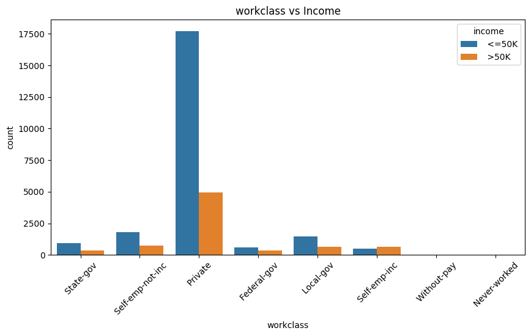

```
🔹 EDUCATION:
income             <=50K       >50K
education
10th           93.354770   6.645230
11th           94.893617   5.106383
12th           92.378753   7.621247
1st-4th        96.428571   3.571429
5th-6th        95.195195   4.804805
7th-8th        93.808050   6.191950
9th            94.747082   5.252918
Assoc-acdm     75.164011  24.835989
Assoc-voc      73.878437  26.121563
Bachelors      58.524743  41.475257
Doctorate      25.907990  74.092010
HS-grad        84.049138  15.950862
Masters        44.341265  55.658735
Preschool     100.000000   0.000000
Prof-school    26.562500  73.437500
Some-college   80.976546  19.023454
```

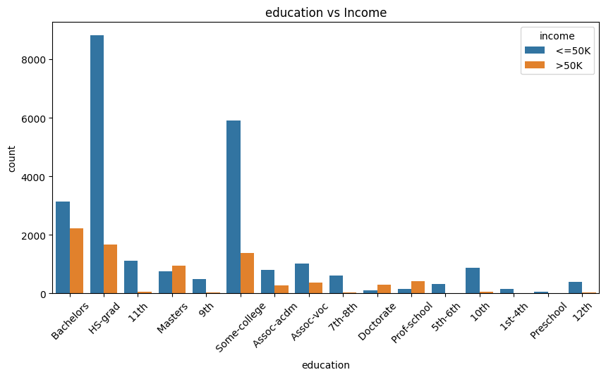

```
🔹 MARITAL-STATUS:
income                     <=50K       >50K
marital-status
Divorced               89.579113  10.420887
Married-AF-spouse      56.521739  43.478261
Married-civ-spouse     55.315171  44.684829
Married-spouse-absent  91.866029   8.133971
Never-married          95.403913   4.596087
Separated              93.560976   6.439024
Widowed                91.440081   8.559919
```

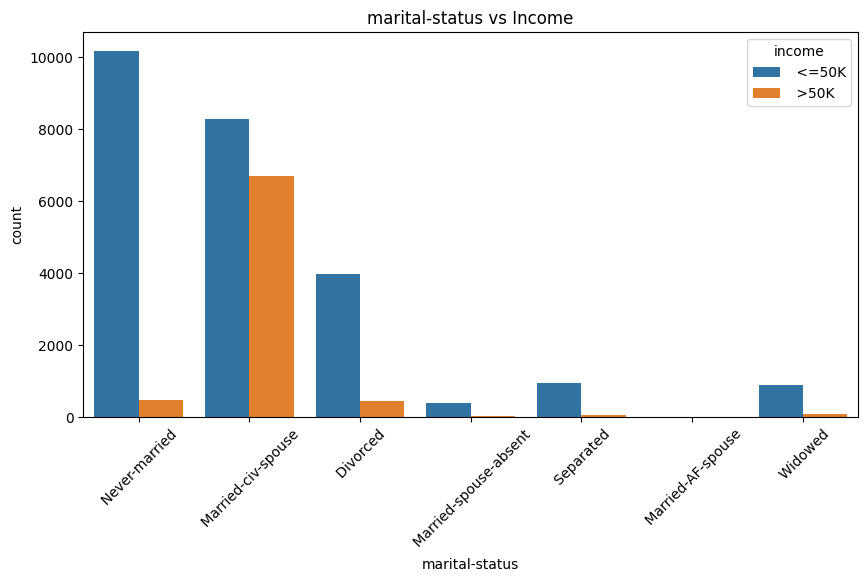

```
🔹 OCCUPATION:
income                 <=50K       >50K
occupation
Adm-clerical       86.551724  13.448276
Armed-Forces       88.888889  11.111111
Craft-repair       77.335936  22.664064
Exec-managerial    51.598623  48.401377
Farming-fishing    88.430584  11.569416
Handlers-cleaners  93.722628   6.277372
Machine-op-inspct  87.512488  12.487512
Other-service      95.842185   4.157815
Priv-house-serv    99.328859   0.671141
Prof-specialty     55.096618  44.903382
Protective-serv    67.488444  32.511556
Sales              73.068493  26.931507
Tech-support       69.504310  30.495690
Transport-moving   79.962430  20.037570
```

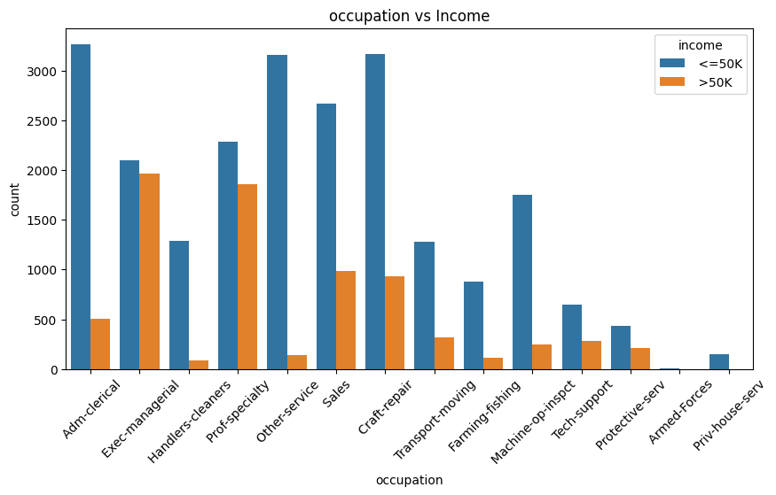

```
🔹 RELATIONSHIP:
income              <=50K       >50K
relationship
Husband         55.142879  44.857121
Not-in-family   89.692956  10.307044
Other-relative  96.228338   3.771662
Own-child       98.677979   1.322021
Unmarried       93.673825   6.326175
Wife            52.487245  47.512755
```

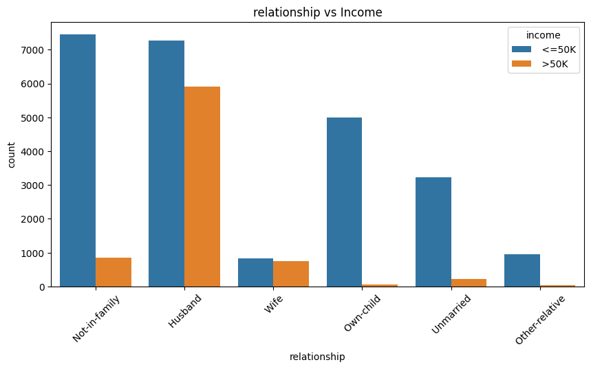

```
🔹 RACE:
income                  <=50K       >50K
race
Amer-Indian-Eskimo  88.424437  11.575563
Asian-Pac-Islander  73.435996  26.564004
Black               87.612036  12.387964
Other               90.774908   9.225092
White               74.414006  25.585994
```

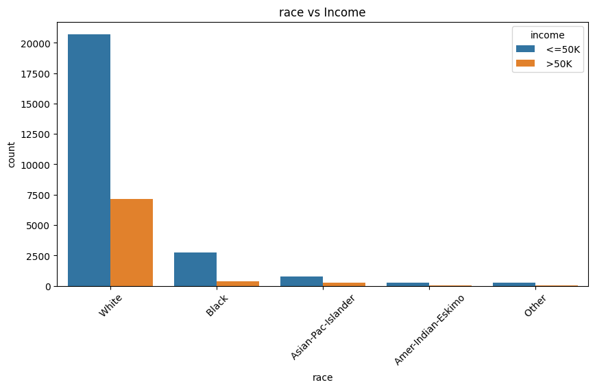

```
🔹 SEX:
income      <=50K       >50K
sex
Female  89.053941  10.946059
Male    69.426342  30.573658
```

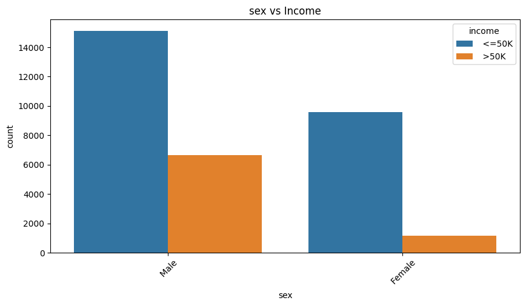

```
🔹 NATIVE-COUNTRY:
income                           <=50K       >50K
native-country
Cambodia                     63.157895  36.842105
Canada                       67.768595  32.231405
China                        73.333333  26.666667
Columbia                     96.610169   3.389831
Cuba                         73.684211  26.315789
Dominican-Republic           97.142857   2.857143
Ecuador                      85.714286  14.285714
El-Salvador                  91.509434   8.490566
England                      66.666667  33.333333
France                       58.620690  41.379310
Germany                      67.883212  32.116788
Greece                       72.413793  27.586207
Guatemala                    95.312500   4.687500
Haiti                        90.909091   9.090909
Holand-Netherlands          100.000000   0.000000
Honduras                     92.307692   7.692308
Hong                         70.000000  30.000000
Hungary                      76.923077  23.076923
India                        60.000000  40.000000
Iran                         58.139535  41.860465
Ireland                      79.166667  20.833333
Italy                        65.753425  34.246575
Jamaica                      87.654321  12.345679
Japan                        61.290323  38.709677
Laos                         88.888889  11.111111
Mexico                       94.867807   5.132193
Nicaragua                    94.117647   5.882353
Outlying-US(Guam-USVI-etc)  100.000000   0.000000
Peru                         93.548387   6.451613
Philippines                  69.191919  30.808081
Poland                       80.000000  20.000000
Portugal                     89.189189  10.810811
Puerto-Rico                  89.473684  10.526316
Scotland                     75.000000  25.000000
South                        80.000000  20.000000
Taiwan                       60.784314  39.215686
Thailand                     83.333333  16.666667
Trinadad&Tobago              89.473684  10.526316
United-States                75.416524  24.583476
Vietnam                      92.537313   7.462687
Yugoslavia                   62.500000  37.500000
```

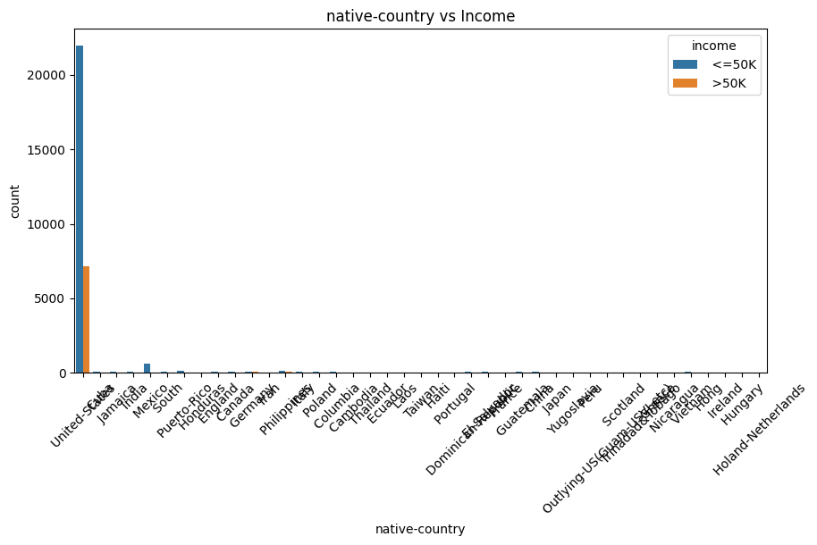

```python
# Cruce con la variable objetivo
for col in cat_cols[:-1]:
    print(f"\n🔹 {col.upper()}:")
    print(pd.crosstab(df_train[col], df_train['income'], normalize='index') * 100)
    plt.figure(figsize=(10, 5))
    sns.countplot(x=col, hue='income', data=df_train)
    plt.xticks(rotation=45)
    plt.title(f'{col} vs Income')
    plt.show()
```

### Insights

- En las variables con muchas categorías deberíamos agruparlas en grupos más generales para reducir su número, ya que podrían generar sesgos indeseados en el modelo.
- Por ejemplo, en native-country tenemos una sola persona de Holanda con ingresos menores a 50K. Este valor no es representativo, por lo que convendría agrupar los países con pocos registros en una categoría más amplia, como Europa, siempre que haya suficientes datos.

## 5. Análisis de variables numéricas

```python
# Identificar variables categóricas
num_cols = df_train.select_dtypes(include=['int64', 'float64']).columns
print("Variables numéricas:", list(num_cols))
```

```
Variables numéricas: ['age', 'fnlwgt', 'education-num', 'capital-gain', 'capital-loss', 'hours-per-week']
```

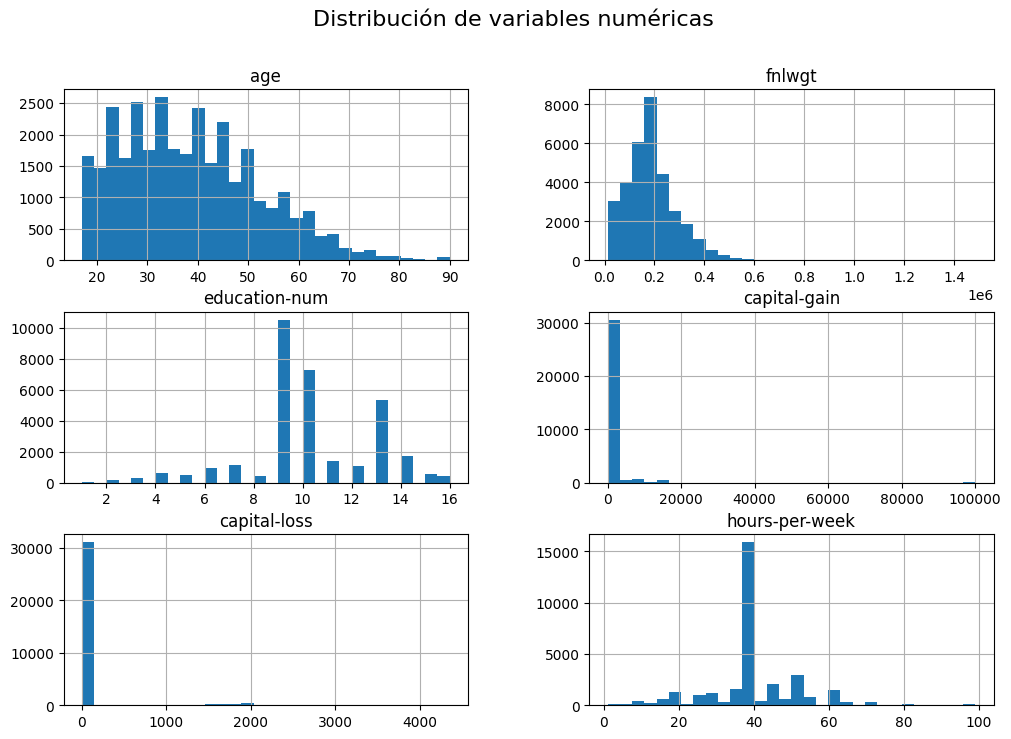

```python
# Histogramas
df_train[num_cols].hist(figsize=(12, 8), bins=30)
plt.suptitle("Distribución de variables numéricas", fontsize=16)
plt.show()
```

### Insights

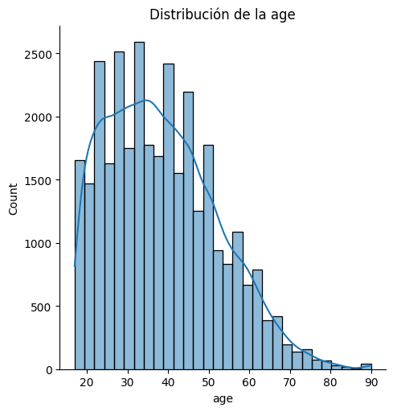

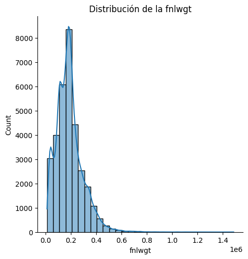

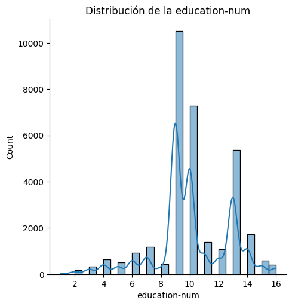

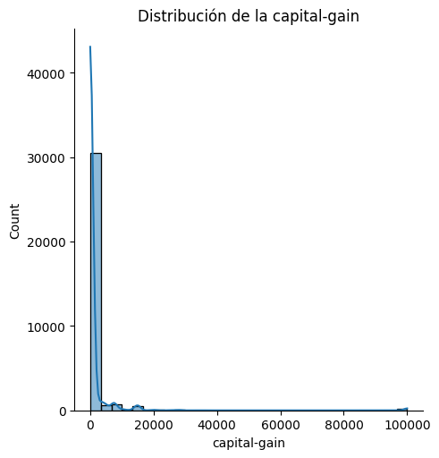

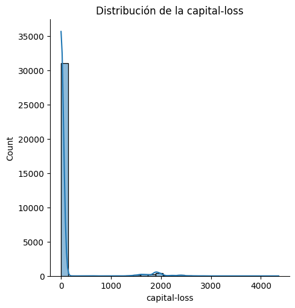

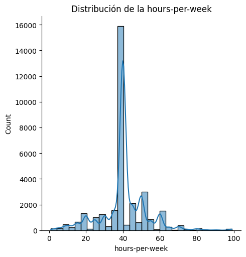

```python
for col in num_cols:
    sns.displot(df_train[col], kde=True, bins=30)
    plt.title(f"Distribución de la {col}")
    plt.show()
```

```python
# Detección de outlier
for col in num_cols:
    Q1 = df_train[col].quantile(0.25)
    Q3 = df_train[col].quantile(0.75)
    IQR = Q3 - Q1
    outliers = ((df_train[col] < (Q1 - 1.5*IQR)) | (df_train[col] > (Q3 + 1.5*IQR))).sum()
    print(f"{col}: {outliers} outliers ({round(outliers/len(df_train)*100,2)}%)")
```

```
age: 143 outliers (0.44%)
fnlwgt: 992 outliers (3.05%)
education-num: 1198 outliers (3.68%)
capital-gain: 2712 outliers (8.33%)
capital-loss: 1519 outliers (4.67%)
hours-per-week: 9008 outliers (27.66%)
```

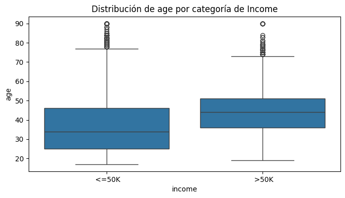

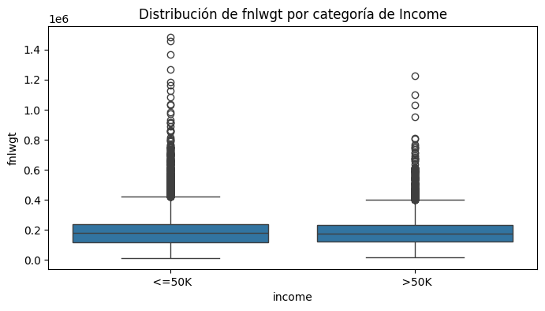

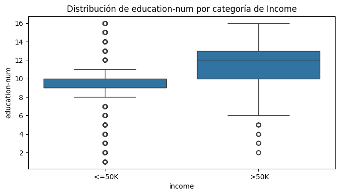

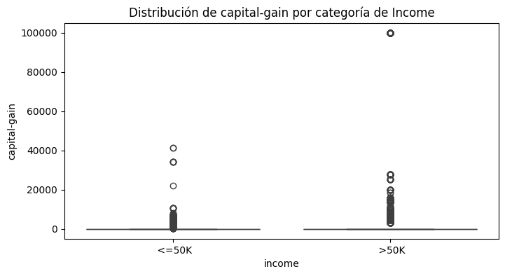

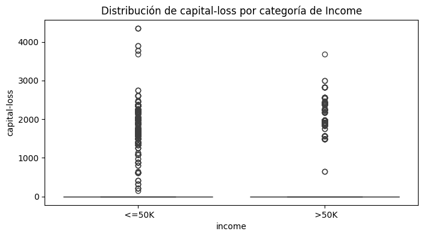

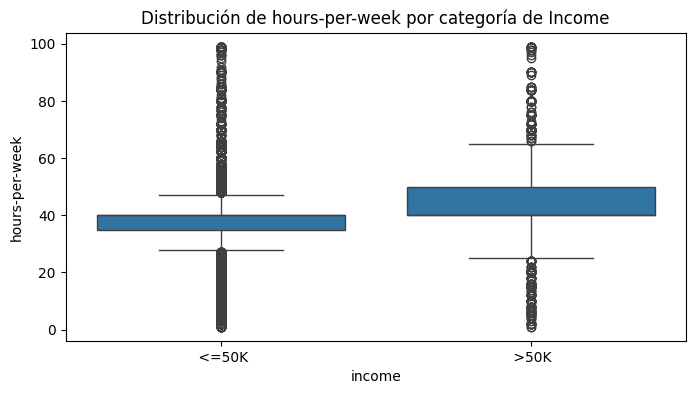

```python
for col in num_cols:
    plt.figure(figsize=(8,4))
    sns.boxplot(x='income', y=col, data=df_train)
    plt.title(f'Distribución de {col} por categoría de Income')
    plt.show()
```

### Insights

- Hay demasiados outliers; dependiendo del modelo que queramos usar, tendremos que tratarlos de una forma u otra.
- Para modelos como XGBoost no sería necesario, pero para una regresión logística sí, por ejemplo aplicando una transformación logarítmica o utilizando winsorization.

```python
num_cols
```

```
Index(['age', 'fnlwgt', 'education-num', 'capital-gain', 'capital-loss',
       'hours-per-week'],
      dtype='object')
```

## 6. Correlación entre variables numéricas

```python
# Seleccionar solo variables numéricas
num_cols = ['age', 'fnlwgt', 'capital-gain', 'capital-loss']

# Calcular matriz de correlación
corr_matrix = df_train[num_cols].corr()

# Mostrar las primeras filas
print(corr_matrix)
```

```
                   age    fnlwgt  capital-gain  capital-loss
age           1.000000 -0.076646      0.077674      0.057775
fnlwgt       -0.076646  1.000000      0.000432     -0.010252
capital-gain  0.077674  0.000432      1.000000     -0.031615
capital-loss  0.057775 -0.010252     -0.031615      1.000000
```

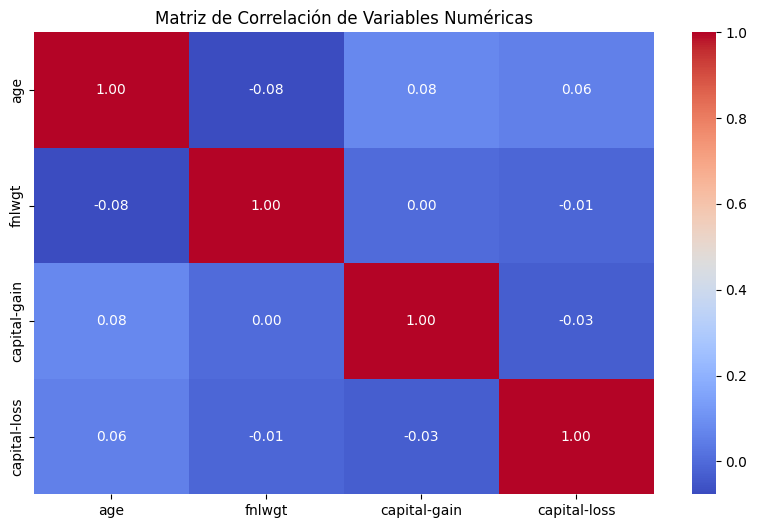

```python
plt.figure(figsize=(10, 6))
sns.heatmap(corr_matrix, annot=True, fmt=".2f", cmap='coolwarm', cbar=True)
plt.title("Matriz de Correlación de Variables Numéricas")
plt.show()
```

### Insights

- Parece que no existe colinealidad entre las variables numéricas; de haberla, podría representar un problema para modelos como la regresión logística.

## 8. Codificación de variables categóricas

### Insights

- Una vez completados los análisis adicionales, se realizará un ajuste sobre ciertas variables categóricas para optimizar su representación en el modelo.

#### NATIVE-COUNTRY: EEUU y Continentes

```python
continent_map = {
    # América
    'Canada': 'America',
    'Cuba': 'America',
    'Jamaica': 'America',
    'Mexico': 'America',
    'Puerto-Rico': 'America',
    'Honduras': 'America',
    'Columbia': 'America',
    'Haiti': 'America',
    'Dominican-Republic': 'America',
    'El-Salvador': 'America',
    'Guatemala': 'America',
    'Trinadad&Tobago': 'America',
    'Nicaragua': 'America',
    'Outlying-US(Guam-USVI-etc)': 'America',
    'Ecuador': 'America',
    'Peru': 'America',
    'South': 'America',

    # Europa
    'England': 'Europe',
    'Germany': 'Europe',
    'Italy': 'Europe',
    'Poland': 'Europe',
    'Portugal': 'Europe',
    'France': 'Europe',
    'Yugoslavia': 'Europe',
    'Scotland': 'Europe',
    'Greece': 'Europe',
    'Ireland': 'Europe',
    'Hungary': 'Europe',
    'Holand-Netherlands': 'Europe',

    # Asia
    'India': 'Asia',
    'Iran': 'Asia',
    'Philippines': 'Asia',
    'Cambodia': 'Asia',
    'Thailand': 'Asia',
    'Laos': 'Asia',
    'Taiwan': 'Asia',
    'China': 'Asia',
    'Japan': 'Asia',
    'Vietnam': 'Asia',
    'Hong': 'Asia',  # Hong Kong
}
```

```python
# Reconteo de con la nueva columna
df_train['continent'] = df_train['native-country'].replace(' United-States', 'United-States') \
    .str.strip() \
    .replace(continent_map)
```

```python
print(df_train['continent'].value_counts(dropna=False))
```

```
continent
United-States    29170
America           1616
Asia               671
NaN                583
Europe             521
Name: count, dtype: int64
```

```
🔹 continent:
income             <=50K       >50K
continent
America        89.727723  10.272277
Asia           69.299553  30.700447
Europe         70.825336  29.174664
United-States  75.416524  24.583476
```

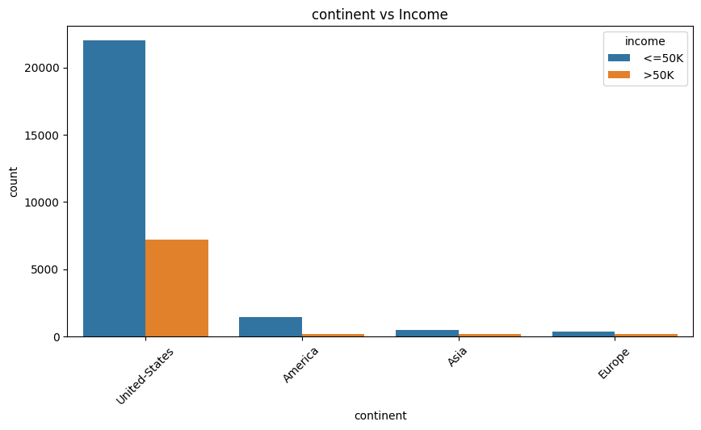

```python
print("\n🔹 continent:")
print(pd.crosstab(df_train['continent'], df_train['income'], normalize='index') * 100)
plt.figure(figsize=(10, 5))
sns.countplot(x='continent', hue='income', data=df_train)
plt.xticks(rotation=45)
plt.title('continent vs Income')
plt.show()
```

#### education-num: agrupar primaria, secundaria, universidad, postgrado

```python
def group_education(num):
    if num <= 4:
        return 'Primaria'
    elif num <= 9:
        return 'Secundaria'
    elif num <= 12:
        return 'Universidad'
    else:
        return 'Postgrado'

df_train['education_group'] = df_train['education-num'].apply(group_education)
print(df_train['education_group'].value_counts())
```

```
education_group
Secundaria     13556
Universidad     9740
Postgrado       8067
Primaria        1198
Name: count, dtype: int64
```

```
🔹 education_group:
income               <=50K       >50K
education_group
Postgrado        51.543325  48.456675
Primaria         94.824708   5.175292
Secundaria       86.301269  13.698731
Universidad      79.332649  20.667351
```

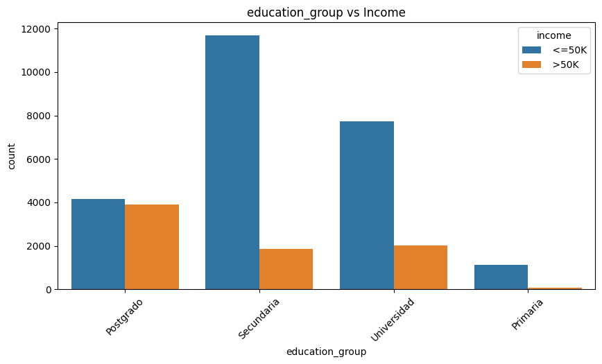

```python
print("\n🔹 education_group:")
print(pd.crosstab(df_train['education_group'], df_train['income'], normalize='index') * 100)
plt.figure(figsize=(10, 5))
sns.countplot(x='education_group', hue='income', data=df_train)
plt.xticks(rotation=45)
plt.title('education_group vs Income')
plt.show()
```

### Insights

- Esta variable es la misma que education, por lo que ambas serán sustituidas por education_group.

#### Hours-per-week: agruparemos en tres categorías: part-time, full-time y extended.

```python
print(f"\n📊 hour-per-week - Frecuencias absolutas:")
print(df_train['hours-per-week'].value_counts())

print("\n📊 Frecuencias relativas (%):")
print(df_train['hours-per-week'].value_counts(normalize=True) * 100)
```

```
📊 hour-per-week - Frecuencias absolutas:
hours-per-week
40    15217
50     2819
45     1824
60     1475
35     1297
      ...
87        1
82        1
94        1
92        1
74        1
Name: count, Length: 94, dtype: int64

📊 Frecuencias relativas (%):
hours-per-week
40    46.733823
50     8.657597
45     5.601794
60     4.529959
35     3.983293
        ...
87     0.003071
82     0.003071
94     0.003071
92     0.003071
74     0.003071
Name: proportion, Length: 94, dtype: float64
```

```python
df_train['hours-per-week'].unique()
```

```
array([40, 13, 16, 45, 50, 80, 30, 35, 60, 20, 52, 44, 15, 25, 38, 43, 55,
       48, 58, 32, 70,  2, 22, 56, 41, 28, 36, 24, 46, 42, 12, 65,  1, 10,
       34, 75, 98, 33, 54,  8,  6, 64, 19, 18, 72,  5,  9, 47, 37, 21, 26,
       14,  4, 59,  7, 99, 53, 39, 62, 57, 78, 90, 66, 11, 49, 84,  3, 17,
       68, 27, 85, 31, 51, 77, 63, 23, 87, 88, 73, 89, 97, 94, 29, 96, 67,
       82, 86, 91, 81, 76, 92, 61, 74, 95])
```

```python
def categorize_hours(h):
    if h < 35:
        return 'Part-time'
    elif h <= 50:
        return 'Full-time'
    else:
        return 'Extended'
```

```python
df_train['work_category'] = df_train['hours-per-week'].apply(lambda x: categorize_hours(x))
```

```python
print(f"\n📊 work_category - Frecuencias absolutas:")
print(df_train['work_category'].value_counts())

print("\n📊 Frecuencias relativas (%):")
print(df_train['work_category'].value_counts(normalize=True) * 100)
```

```
📊 work_category - Frecuencias absolutas:
work_category
Full-time    23335
Part-time     5583
Extended      3643
Name: count, dtype: int64

📊 Frecuencias relativas (%):
work_category
Full-time    71.665489
Part-time    17.146279
Extended     11.188231
Name: proportion, dtype: float64
```

```
🔹 work_category:
income             <=50K       >50K
work_category
Extended       58.715344  41.284656
Full-time      74.501821  25.498179
Part-time      93.068243   6.931757
```

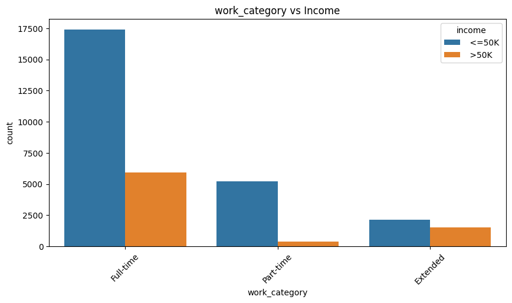

```python
print("\n🔹 work_category:")
print(pd.crosstab(df_train['work_category'], df_train['income'], normalize='index') * 100)
plt.figure(figsize=(10, 5))
sns.countplot(x='work_category', hue='income', data=df_train)
plt.xticks(rotation=45)
plt.title('work_category vs Income')
plt.show()
```

## 9. OHE de variables categóricas

### Insights

- Se aplicará OHE a la variables categóricas